# Final Project

Ruhama Baruda @02966062

## Importing Libraries

This project uses Pandas and NumPy for data wrangling, and Matplotlib and Seaborn for visualizing Olympic trends and distributions.

```python
# Importing libraries for data wrangling
import pandas as pd
import numpy as np

# Importing libraries for data visualization
import matplotlib.pyplot as plt
import seaborn as sns

#Suppressing warnings for a cleaner output
import warnings
warnings.filterwarnings("ignore")
```

This section will explore the structure and composition of the Olympic dataset.

## Dataset Description and Source

This dataset, titled **"120 Years of Olympic History: Athletes and Results"**, provides comprehensive information on all athletes who have competed in the modern Olympic Games from **Athens 1896 to Rio 2016**. Each row in the dataset represents a single athlete’s participation in a specific event. The data contains both Summer and Winter Games data, which were held in the same year until 1992 and staggered thereafter.

**Source:** The data was scraped from sports-reference.com and made available on Kaggle.

**Key Columns:**

**Name, Sex, Age, Height, Weight** — Athlete demographics

**Team, NOC** — Country representation

**Sport, Event** — Event classification

**Year, Season, City** — Temporal and spatial context

**Medal** — Awarded medal (Gold, Silver, Bronze, or NA)

## Data Understanding and Cleaning

This section will explore the structure of the dataset and identify missing or inconsistent values.

### Importing the dataset

```python
#load dataset from csv
olympics_df = pd.read_csv("athlete_events.csv")

#display first 10 rows
olympics_df.head(10)
```

|  | ID | Name | Sex | Age | Height | Weight | Team | NOC | Games | Year | Season | City | Sport | Event | Medal |
| --- | --- | --- | --- | --- | --- | --- | --- | --- | --- | --- | --- | --- | --- | --- | --- |
| 0 | 1 | A Dijiang | M | 24.0 | 180.0 | 80.0 | China | CHN | 1992 Summer | 1992 | Summer | Barcelona | Basketball | Basketball Men's Basketball | NaN |
| 1 | 2 | A Lamusi | M | 23.0 | 170.0 | 60.0 | China | CHN | 2012 Summer | 2012 | Summer | London | Judo | Judo Men's Extra-Lightweight | NaN |
| 2 | 3 | Gunnar Nielsen Aaby | M | 24.0 | NaN | NaN | Denmark | DEN | 1920 Summer | 1920 | Summer | Antwerpen | Football | Football Men's Football | NaN |
| 3 | 4 | Edgar Lindenau Aabye | M | 34.0 | NaN | NaN | Denmark/Sweden | DEN | 1900 Summer | 1900 | Summer | Paris | Tug-Of-War | Tug-Of-War Men's Tug-Of-War | Gold |
| 4 | 5 | Christine Jacoba Aaftink | F | 21.0 | 185.0 | 82.0 | Netherlands | NED | 1988 Winter | 1988 | Winter | Calgary | Speed Skating | Speed Skating Women's 500 metres | NaN |
| 5 | 5 | Christine Jacoba Aaftink | F | 21.0 | 185.0 | 82.0 | Netherlands | NED | 1988 Winter | 1988 | Winter | Calgary | Speed Skating | Speed Skating Women's 1,000 metres | NaN |
| 6 | 5 | Christine Jacoba Aaftink | F | 25.0 | 185.0 | 82.0 | Netherlands | NED | 1992 Winter | 1992 | Winter | Albertville | Speed Skating | Speed Skating Women's 500 metres | NaN |
| 7 | 5 | Christine Jacoba Aaftink | F | 25.0 | 185.0 | 82.0 | Netherlands | NED | 1992 Winter | 1992 | Winter | Albertville | Speed Skating | Speed Skating Women's 1,000 metres | NaN |
| 8 | 5 | Christine Jacoba Aaftink | F | 27.0 | 185.0 | 82.0 | Netherlands | NED | 1994 Winter | 1994 | Winter | Lillehammer | Speed Skating | Speed Skating Women's 500 metres | NaN |
| 9 | 5 | Christine Jacoba Aaftink | F | 27.0 | 185.0 | 82.0 | Netherlands | NED | 1994 Winter | 1994 | Winter | Lillehammer | Speed Skating | Speed Skating Women's 1,000 metres | NaN |

### Understanding the Dataset

```python
#checking for null values
olympics_df.isnull().sum()
```

```
ID             0
Name           0
Sex            0
Age         9474
Height     60171
Weight     62875
Team           0
NOC            0
Games          0
Year           0
Season         0
City           0
Sport          0
Event          0
Medal     231333
dtype: int64
```

```python
#describing the structure of the data
print("The general information of the data:\n")
olympics_df.info()
```

```
The general information of the data:

<class 'pandas.core.frame.DataFrame'>
RangeIndex: 271116 entries, 0 to 271115
Data columns (total 15 columns):
 #   Column  Non-Null Count   Dtype
---  ------  --------------   -----
 0   ID      271116 non-null  int64
 1   Name    271116 non-null  object
 2   Sex     271116 non-null  object
 3   Age     261642 non-null  float64
 4   Height  210945 non-null  float64
 5   Weight  208241 non-null  float64
 6   Team    271116 non-null  object
 7   NOC     271116 non-null  object
 8   Games   271116 non-null  object
 9   Year    271116 non-null  int64
 10  Season  271116 non-null  object
 11  City    271116 non-null  object
 12  Sport   271116 non-null  object
 13  Event   271116 non-null  object
 14  Medal   39783 non-null   object
dtypes: float64(3), int64(2), object(10)
memory usage: 31.0+ MB
```

```python
print("The number of rows and columns of the data:\n")
olympics_df.shape
```

```
The number of rows and columns of the data:
```

```
(271116, 15)
```

```python
#unique value counts
olympics_df.nunique()
```

```
ID        135571
Name      134732
Sex            2
Age           74
Height        95
Weight       220
Team        1184
NOC          230
Games         51
Year          35
Season         2
City          42
Sport         66
Event        765
Medal          3
dtype: int64
```

```python
#checking for duplicate rows
duplicates = olympics_df.duplicated()
duplicates.sum()
```

```
1385
```

```python
#creating a workable copy of the data
df = olympics_df.copy()
```

## Handling Missing Values

```python
#check missing data by column
print("Count of missing values by column:\n")
missing_sum = df.isnull().sum()
missing_sum
```

```
Count of missing values by column:
```

```
ID             0
Name           0
Sex            0
Age         9474
Height     60171
Weight     62875
Team           0
NOC            0
Games          0
Year           0
Season         0
City           0
Sport          0
Event          0
Medal     231333
dtype: int64
```

```python
#percent of missing values
missing_percent = (missing_sum/len(df)) * 100
missing_percent
```

```
ID         0.000000
Name       0.000000
Sex        0.000000
Age        3.494445
Height    22.193821
Weight    23.191180
Team       0.000000
NOC        0.000000
Games      0.000000
Year       0.000000
Season     0.000000
City       0.000000
Sport      0.000000
Event      0.000000
Medal     85.326207
dtype: float64
```

**Observations**

- Medal: 85% missing (expected, since most athletes do not win medals)
- Height and Weight: 22-23% missing
- Age: 3.5% missing

### Filling Missing Values

```python
#filling missing "Medal" values with "No Medal"
df["Medal"].fillna("No Medal", inplace = True)
```

Missing values for Age, Height, and Weight are filled with medians based on Sport and Sex. This approach preserves the physical differences between sports and genders.

No rows were dropped in order to avoid distorting other relevant columns.

#### Age

```python
#create a dataframe with median per sport and sex
age_medians = df.groupby(["Sport", "Sex"])["Age"].median().reset_index()
age_medians.rename(columns = {"Age": "Median_Age"}, inplace = True)

#merge medians back into main dataframe
df = df.merge(age_medians, on = ["Sport","Sex"], how = "left")

#fill missing values with group median
df["Age"].fillna(df["Median_Age"], inplace = True)

#drop helper column
df.drop(columns = ["Median_Age"], inplace = True)
```

#### Height

```python
#create a dataframe with median per sport and sex
height_medians = df.groupby(["Sport", "Sex"])["Height"].median().reset_index()
height_medians.rename(columns = {"Height": "Median_Height"}, inplace = True)

#merge medians back into main dataframe
df = df.merge(height_medians, on = ["Sport","Sex"], how = "left")

#fill missing values with group median
df["Height"].fillna(df["Median_Height"], inplace = True)

#drop helper column
df.drop(columns = ["Median_Height"], inplace = True)
```

#### Weight

```python
#create a dataframe with median per sport and sex
weight_medians = df.groupby(["Sport", "Sex"])["Weight"].median().reset_index()
weight_medians.rename(columns = {"Weight": "Median_Weight"}, inplace = True)

#merge medians back into main dataframe
df = df.merge(weight_medians, on = ["Sport","Sex"], how = "left")

#fill missing values with group median
df["Weight"].fillna(df["Median_Weight"], inplace = True)

#drop helper column
df.drop(columns = ["Median_Weight"], inplace = True)
```

```python
#check for remaining missing values
df.isnull().sum()
```

```
ID             0
Name           0
Sex            0
Age            0
Height       100
Weight       595
Team           0
NOC            0
Games          0
Year           0
Season         0
City           0
Sport          0
Event          0
Medal     231333
dtype: int64
```

```python
#show the unique sports with missing weight
df[df["Weight"].isnull()]["Sport"].unique()
```

```
array(['Art Competitions', 'Polo', 'Cricket', 'Racquets',
       'Military Ski Patrol', 'Croquet', 'Jeu De Paume', 'Roque',
       'Alpinism', 'Basque Pelota', 'Motorboating', 'Aeronautics'],
      dtype=object)
```

```python
#show the unique sports with missing height
df[df["Height"].isnull()]["Sport"].unique()
```

```
array(['Cricket', 'Military Ski Patrol', 'Croquet', 'Roque', 'Alpinism',
       'Basque Pelota', 'Motorboating', 'Aeronautics'], dtype=object)
```

```python
#filling remaining missing values with overall median
df["Height"].fillna(df["Height"].median(), inplace=True)
df["Weight"].fillna(df["Weight"].median(), inplace=True)

#final check for missing values
df.isnull().sum()
```

```
ID             0
Name           0
Sex            0
Age            0
Height         0
Weight         0
Team           0
NOC            0
Games          0
Year           0
Season         0
City           0
Sport          0
Event          0
Medal     231333
dtype: int64
```

After performing group-based median imputation for Height and Weight, I checked which sports still contained missing values.

For Weight, missing values were associated with the following sports: Art Competitions, Polo, Cricket, Racquets, Military Ski Patrol, Croquet, Jeu De Paume, Roque, Alpinism, Basque Pelota, Motorboating, Aeronautics

For Height, the missing values were found in: Cricket, Military Ski Patrol, Croquet, Roque, Alpinism, Basque Pelota, Motorboating, Aeronautics

I filled the remaining missing Height and Weight values using the overall median for each column to preserve all rows while minimizing bias introduced by extreme values or outliers.

## Data Validation

### Removing Duplicate Rows

```python
#check duplicate rows
print("Number of duplicate rows: ")
df.duplicated().sum()
```

```
Number of duplicate rows:
```

```
1385
```

```python
#drop duplicate rows
df.drop_duplicates(inplace = True)

#confirm all duplicates are removed
print("Number of duplicate rows: ")
df.duplicated().sum()
```

```
Number of duplicate rows:
```

```
0
```

There was a total of 1,385 duplicate rows that have now been removed using drop_duplicates().

### Data Types

```python
#check data types
df.dtypes
```

```
ID          int64
Name       object
Sex        object
Age       float64
Height    float64
Weight    float64
Team       object
NOC        object
Games      object
Year        int64
Season     object
City       object
Sport      object
Event      object
Medal      object
dtype: object
```

### Checking for Outliers or Invalid Values

This section will identify negative or zero values in Age, Height, and Weight. Values that look biologically implausible will also be identified (ex: 3-year-old athletes, 500 cm tall competitors, etc).

```python
#check for count of values less than or equal to zero
(df[["Age", "Height", "Weight"]] <= 0).sum()
```

```
Age       0
Height    0
Weight    0
dtype: int64
```

```python
df[["Age", "Height", "Weight"]].describe()
```

|  | Age | Height | Weight |
| --- | --- | --- | --- |
| count | 269731.000000 | 269731.000000 | 269731.000000 |
| mean | 25.488023 | 175.565630 | 71.033928 |
| std | 6.129526 | 9.860563 | 13.284503 |
| min | 10.000000 | 127.000000 | 25.000000 |
| 25% | 22.000000 | 169.000000 | 62.000000 |
| 50% | 25.000000 | 176.000000 | 71.000000 |
| 75% | 28.000000 | 182.000000 | 78.000000 |
| max | 97.000000 | 226.000000 | 214.000000 |

```python
#checking min and max of years to make sure there are none outside of 1896-2016
df["Year"].describe()
```

```
count    269731.000000
mean       1978.623073
std          29.752055
min        1896.000000
25%        1960.000000
50%        1988.000000
75%        2002.000000
max        2016.000000
Name: Year, dtype: float64
```

No anomalies were found

## Additional Cleaning

```python
#renaming "Team" to "Country" for clarity
df.rename(columns={"Team": "Country"}, inplace=True)
```

#### Standardizing Text Columns

```python
#removing spaces and standardizing capitalization
df["Country"] = df["Country"].str.title().str.strip()
df["City"] = df["City"].str.title().str.strip()
df["Sport"] = df["Sport"].str.title().str.strip()
df["Event"] = df["Event"].str.title().str.strip()
```

```python
#check case visually
confirm_textcol = df[["Country", "City", "Sport", "Event"]]
confirm_textcol.head(10)
```

|  | Country | City | Sport | Event |
| --- | --- | --- | --- | --- |
| 0 | China | Barcelona | Basketball | Basketball Men'S Basketball |
| 1 | China | London | Judo | Judo Men'S Extra-Lightweight |
| 2 | Denmark | Antwerpen | Football | Football Men'S Football |
| 3 | Denmark/Sweden | Paris | Tug-Of-War | Tug-Of-War Men'S Tug-Of-War |
| 4 | Netherlands | Calgary | Speed Skating | Speed Skating Women'S 500 Metres |
| 5 | Netherlands | Calgary | Speed Skating | Speed Skating Women'S 1,000 Metres |
| 6 | Netherlands | Albertville | Speed Skating | Speed Skating Women'S 500 Metres |
| 7 | Netherlands | Albertville | Speed Skating | Speed Skating Women'S 1,000 Metres |
| 8 | Netherlands | Lillehammer | Speed Skating | Speed Skating Women'S 500 Metres |
| 9 | Netherlands | Lillehammer | Speed Skating | Speed Skating Women'S 1,000 Metres |

#### New Columns

```python
#column to flag wether an athlete won a medal
df["Is Medalist"] = df["Medal"] != "No Medal"
df["Is Medalist"] = df["Is Medalist"].astype(int)
```

The Is_Medalist column was created to flag whether an athlete won any medal. The column was grouped with a boolean comparison to assign 1 to medalists and 0 otherwise.

```python
#column to group decades
df["Decade"] = (df["Year"] // 10) * 10
```

```python
#column to group by medal type
medal_map = {"Gold": 3, "Silver": 2, "Bronze": 1, "No Medal": 0}
df["Medal Value"] = df["Medal"].map(medal_map)
```

#### Summary of additional cleaning

- The Country column was cleaned for capitalization and spacing.
- New columns were derived to simplify downstream analysis:
- Is Medalist: A binary flag indicating if the athlete received any medal.
- Decade: Created from the Year column to support decadal trend analysis.
- Medal Value: Converted medal types into numeric values (Gold = 3, Silver = 2, Bronze = 1, No Medal = 0).

## EDA

```python
# Total number of unique athletes
total_athletes = df["ID"].nunique()
print("Total unique athletes:", total_athletes)
```

```
Total unique athletes: 135571
```

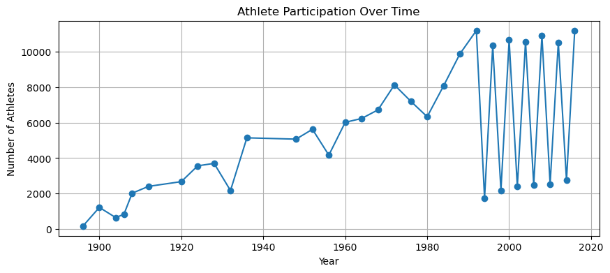

```python
# Participation over time (number of unique athletes per year)
participation_by_year = df.groupby("Year")["ID"].nunique()
participation_by_year.plot(kind="line", marker="o", figsize=(10, 4), title="Athlete Participation Over Time")
plt.xlabel("Year")
plt.ylabel("Number of Athletes")
plt.grid(True)
plt.show()
```

```python
# Countries (or NOCs) with the most Olympic participation
top_countries_by_participation = df["Country"].value_counts().head(10)
top_nocs_by_participation = df["NOC"].value_counts().head(10)
```

```python
# Display top countries
print("Top 10 Countries by Athlete Participation:")
print(top_countries_by_participation)
```

```
Top 10 Countries by Athlete Participation:
Country
United States    17598
France           11817
Great Britain    11264
Italy            10213
Germany           9230
Canada            9226
Japan             8269
Sweden            8004
Australia         7512
Hungary           6492
Name: count, dtype: int64
```

```python
# Top 10 sports with the most distinct events
top_sports_by_event = df.groupby("Sport")["Event"].nunique().sort_values(ascending=False).head(10)
print("Top 10 Sports by Number of Events:")
print(top_sports_by_event)
```

```
Top 10 Sports by Number of Events:
Sport
Shooting            83
Athletics           83
Swimming            55
Cycling             44
Sailing             38
Wrestling           30
Archery             29
Art Competitions    29
Canoeing            27
Gymnastics          27
Name: Event, dtype: int64
```

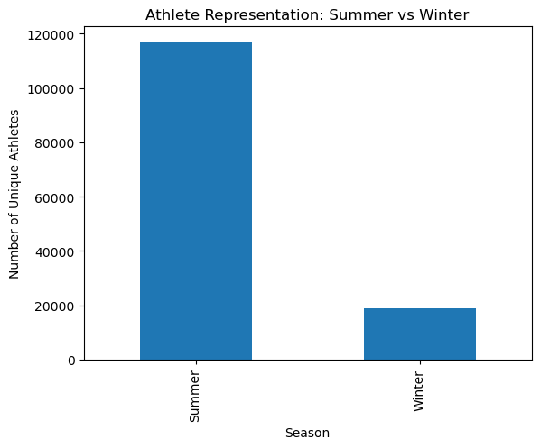

```
Season
Summer    116776
Winter     18958
Name: ID, dtype: int64
```

```python
# Athlete representation by Summer vs. Winter Games
season_comparison = df.groupby("Season")["ID"].nunique()
season_comparison.plot(kind="bar", title="Athlete Representation: Summer vs Winter")
plt.ylabel("Number of Unique Athletes")
plt.show()
print(season_comparison)
```

## Data Viz and interpretation

### 1. Medal Trends Over Time by Gender

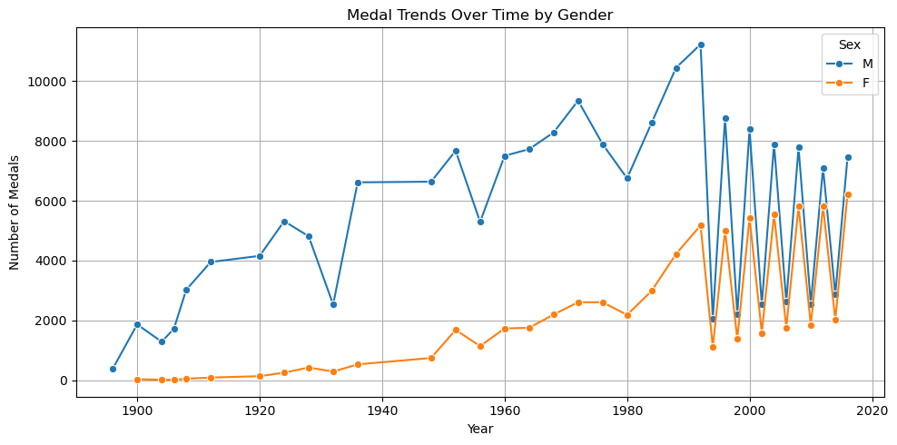

```python
# Medal trends over time by gender
medalists = df[df["Medal"] != "No Medal"]
gender_trend = medalists.groupby(["Year", "Sex"]).size().reset_index(name="Medal Count")

plt.figure(figsize=(10, 5))
sns.lineplot(data=gender_trend, x="Year", y="Medal Count", hue="Sex", marker="o")
plt.title("Medal Trends Over Time by Gender")
plt.xlabel("Year")
plt.ylabel("Number of Medals")
plt.grid(True)
plt.tight_layout()
plt.show()
```

#### Interpretation

This line chart shows how medal counts have grown over time for both male and female athletes. You can immediately see a sharp increase in female medalists from the 1980s onward, reflecting global progress in gender inclusion in sports.

### Heatmap of Medals by Sport and Year

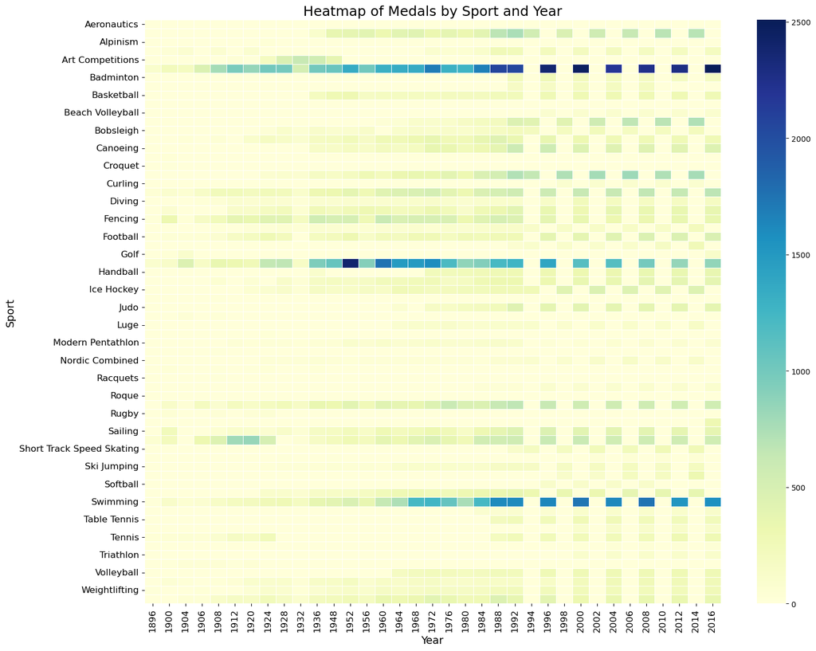

```python
# Filter data to include only medalists
medalists = df[df["Medal"] != "No Medal"]

# Group by Sport and Year to count medals
heatmap_data = medalists.groupby(["Sport", "Year"]).size().unstack(fill_value=0)

# Plot heatmap with larger axis labels and tick sizes
plt.figure(figsize=(16, 12))
sns.heatmap(heatmap_data, cmap="YlGnBu", linewidths=0.5)

plt.title("Heatmap of Medals by Sport and Year", fontsize=18)
plt.xlabel("Year", fontsize=14)
plt.ylabel("Sport", fontsize=14)
plt.xticks(fontsize=12)
plt.yticks(fontsize=12)

plt.tight_layout()
plt.show()
```

#### Interpretation

A heatmap of medal counts by sport and year highlights event concentration. Sports like Athletics, Swimming, and Gymnastics consistently appear across decades with high medal volumes. Others, such as Art Competitions, appear briefly and then disappear, reflecting changes in Olympic programming.

### Athlete Count vs. Medals Won

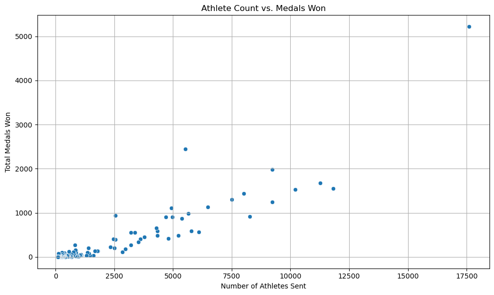

```python
# Athlete count vs. medals won by country
common_countries = country_athletes[country_athletes > 100].index.intersection(country_medals.index)

plot_df = pd.DataFrame({
    "Country": common_countries,
    "Athletes": country_athletes[common_countries],
    "Medals": country_medals[common_countries]
})

plt.figure(figsize=(10, 6))
sns.scatterplot(data=plot_df, x="Athletes", y="Medals")
plt.title("Athlete Count vs. Medals Won")
plt.xlabel("Number of Athletes Sent")
plt.ylabel("Total Medals Won")
plt.grid(True)
plt.tight_layout()
plt.savefig("athlete_medals.png", dpi=300, bbox_inches="tight")
plt.show()
```

```python
#Correlation Coefficient
correlation = plot_df["Athletes"].corr(plot_df["Medals"])
print("Correlation between Athlete Count and Medals Won:", correlation)
```

```
Correlation between Athlete Count and Medals Won: 0.9031828533980105
```

#### Interpretation:

Countries that send more athletes tend to win more medals — though there are some notable overperformers with smaller teams.

r = 0.90

- strong positive correlation

### Medals by Season

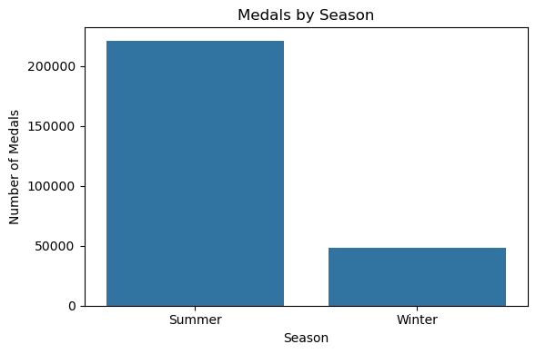

```python
# Bar plot of total medals by season
season_medals = medalists["Season"].value_counts()

plt.figure(figsize=(6, 4))
sns.barplot(x=season_medals.index, y=season_medals.values)
plt.title("Medals by Season")
plt.xlabel("Season")
plt.ylabel("Number of Medals")
plt.tight_layout()
plt.show()
```

### BMI Distribution by Sport (Top 10)

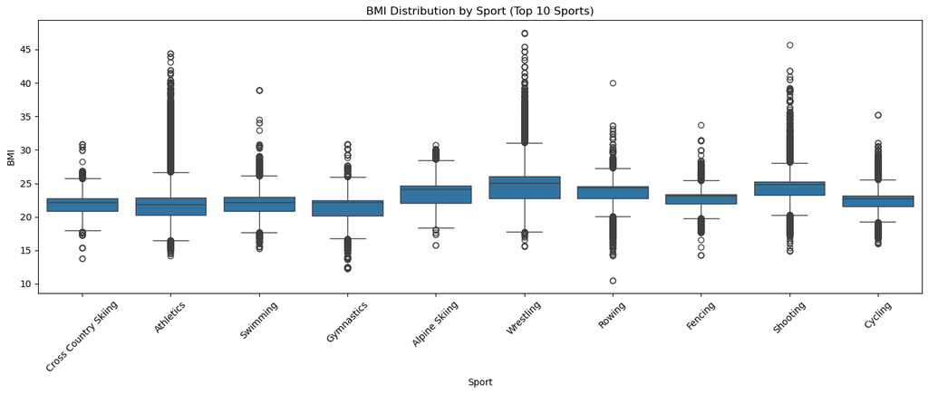

```python
# BMI distribution by sport
df["BMI"] = df["Weight"] / ((df["Height"] / 100) ** 2)

# Only include valid rows with non-null BMI values
top_10_sports = df["Sport"].value_counts().head(10).index
bmi_data = df[df["Sport"].isin(top_10_sports) & df["BMI"].notnull()]

plt.figure(figsize=(14, 6))
sns.boxplot(data=bmi_data, x="Sport", y="BMI")
plt.title("BMI Distribution by Sport (Top 10 Sports)")
plt.xticks(rotation=45)
plt.tight_layout()
plt.show()
```

#### Correlation between BMI and Medal

```python
# Calculate correlation between BMI and medal value
bmi_corr_df = df[["BMI", "Medal Value"]].dropna()
bmi_medal_corr = bmi_corr_df["BMI"].corr(bmi_corr_df["Medal Value"])
print("Correlation between BMI and Medal Value:", bmi_medal_corr)
```

```
Correlation between BMI and Medal Value: 0.007077832280251383
```

#### Interpretation

r = 0.01

Correlation between BMI and medal outcomes is extremely weak. There is no universal physical advantage across the Olympix. More context is necessary, as body types likely correspond with specific sports.

### Height Distribution of Medalists by Gender

- Are there significant differences in the height distributions of male and female medalists?

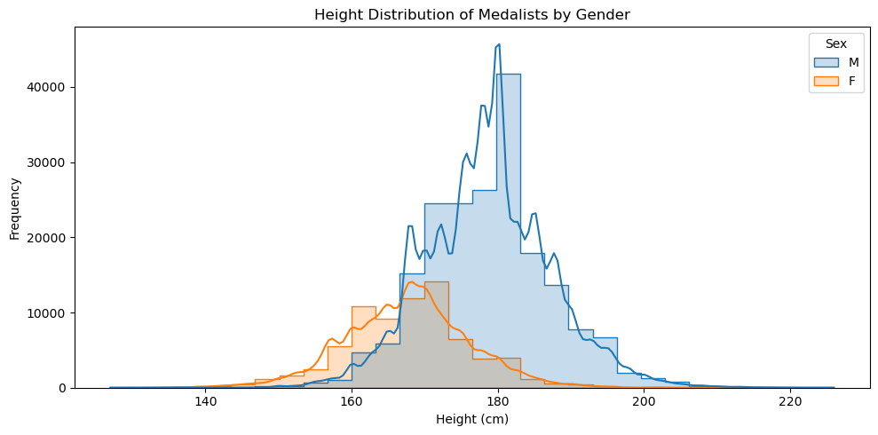

```python
medalists = df[df["Medal"] != "No Medal"]

plt.figure(figsize=(10, 5))
sns.histplot(
    data=medalists,         # only include medal-winning athletes
    x="Height",             # analyzing the 'Height' column
    hue="Sex",              # separate by 'Sex' (Male/Female)
    kde=True,               # add smoothed curve (Kernel Density Estimation)
    element="step",         # plot lines instead of filled bars
    bins=30                 # use 30 height intervals
)
plt.title("Height Distribution of Medalists by Gender")
plt.xlabel("Height (cm)")
plt.ylabel("Frequency")
plt.tight_layout()
plt.show()
```

There are notable differences in height distributions, as the majority of men are between 175-190 cm while most female medalists fall between 160 and 175.

## Gender Representation Over Time

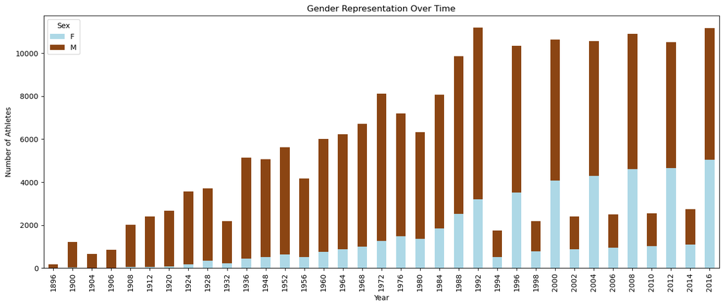

```python
#group by Year and Sex and count athletes
gender_year = df.groupby(["Year", "Sex"])["ID"].nunique().unstack().fillna(0)

#creating a stacked bar chart
gender_year.plot(
    kind="bar",
    stacked=True,
    figsize=(14, 6),
    color={"F": "lightblue", "M": "saddlebrown"}
)

plt.title("Gender Representation Over Time")
plt.xlabel("Year")
plt.ylabel("Number of Athletes")
plt.legend(title="Sex")
plt.tight_layout()
plt.savefig("gender_representation.png", dpi = 200, bbox_inches = "tight")
plt.show()
```

## Interpretation

This stacked bar chart by year shows increasing gender parity over time from 1896 to 2016. In the earliest Games, participation was entirely male, with the first women competing in 1900. The most dramatic increase in female athlete representation occurred post-1980

# Insights and Generalizations

```python
#pip install kaleido to export plotly graphs
!pip install -U kaleido
```

```python
#importing plotly for advanced visualizations
import plotly.express as px

# interactive line chart for average athlete age over time
age_trend = df[df["Age"].notnull()].groupby("Year")["Age"].mean().reset_index()

# Interactive line chart for average age
fig1 = px.line(
    age_trend,
    x="Year", y="Age",
    title="Average Athlete Age Over Time",
    markers=True,
    labels={"Age": "Average Age"}
)
fig1.write_html("avgage_time.html")
fig1.show()
```

[interactive chart not shown]

## Total Medals by Global Region

```python
#Create a mapping from NOC to general region (simplified)
region_map = {
    "USA": "North America", "CAN": "North America", "MEX": "North America",
    "BRA": "South America", "ARG": "South America", "COL": "South America",
    "GBR": "Europe", "FRA": "Europe", "GER": "Europe", "ITA": "Europe", "RUS": "Europe",
    "CHN": "Asia", "JPN": "Asia", "KOR": "Asia", "IND": "Asia",
    "KEN": "Africa", "RSA": "Africa", "ETH": "Africa", "NGR": "Africa",
    "AUS": "Oceania", "NZL": "Oceania"
}
```

```python
#Apply region labels
df["Region"] = df["NOC"].map(region_map)
```

```python
#Filter and group by Region
regional_medals = df[df["Medal"] != "No Medal"].dropna(subset=["Region"])
region_counts = regional_medals["Region"].value_counts().reset_index()
region_counts.columns = ["Region", "Medal Count"]
```

```python
# Create bar chart
fig2 = px.bar(
    region_counts,
    x="Region", y="Medal Count",
    title="Total Olympic Medals by Global Region",
    color="Region"
)
fig2.write_html("medal_global.html")
fig2.show()
```

[interactive chart not shown]

### Interpretation

This chart shows how medal counts cluster across global regions. Europe has historically dominated, but Asia and North America show increasing influence. Regional disparities also reflect access, economic investment in sport, and geopolitical visibility.

## Medal Count by Gender Across Decades

```python
# Group by Decade and Gender, filtering for medalists only
decade_gender = df[df["Medal"] != "No Medal"].groupby(["Decade", "Sex"]).size().reset_index(name="Medal Count")

# Create grouped bar chart
fig = px.bar(
    decade_gender,
    x="Decade", y="Medal Count", color="Sex",
    barmode="group",
    title="Medal Count by Gender Across Decades",
    labels={"Medal Count": "Number of Medals"}
)

# Show the plot
fig.write_html("medal_trend_decade.html")
fig.show()
```

[interactive chart not shown]

### Interpretation

Visualizes the rise in female medal counts across time, especially from the 1980s onward.

# Conclusioin